# Practice Exercises

Lillian Clark

3/3/2021

```r
#install.packages("tidyverse")
#install.packages("dplyr")
#install.packages("ggplot2")
```

```r
library(tidyverse)
library(dplyr)
library(ggplot2)
```

Today we’ll be using a dataset about mammalian sleep that comes built in to ggplot2.

```r
msleep
```

```
## # A tibble: 83 x 11
##    name  genus vore  order conservation sleep_total sleep_rem sleep_cycle awake
##    <chr> <chr> <chr> <chr> <chr>              <dbl>     <dbl>       <dbl> <dbl>
##  1 Chee… Acin… carni Carn… lc                  12.1      NA        NA      11.9
##  2 Owl … Aotus omni  Prim… <NA>                17         1.8      NA       7
##  3 Moun… Aplo… herbi Rode… nt                  14.4       2.4      NA       9.6
##  4 Grea… Blar… omni  Sori… lc                  14.9       2.3       0.133   9.1
##  5 Cow   Bos   herbi Arti… domesticated         4         0.7       0.667  20
##  6 Thre… Brad… herbi Pilo… <NA>                14.4       2.2       0.767   9.6
##  7 Nort… Call… carni Carn… vu                   8.7       1.4       0.383  15.3
##  8 Vesp… Calo… <NA>  Rode… <NA>                 7        NA        NA      17
##  9 Dog   Canis carni Carn… domesticated        10.1       2.9       0.333  13.9
## 10 Roe … Capr… herbi Arti… lc                   3        NA        NA      21
## # … with 73 more rows, and 2 more variables: brainwt <dbl>, bodywt <dbl>
```

You usually won’t be working with data that’s already built into R, so for practice we’re going to read in the same `msleep` data as a CSV file.

```r
mammal <- read_csv("data/mammal-sleep.csv")
```

### Exercise 1

**What are the dimensions of `mammal()`? How many rows and columns does it have?**

Type `head(mammal)` in the Console window. What does this do? How about `tail(mammal)`?

### Exercise 2

Let’s do some exploratory data analysis and look at summary statistics!

You’ve learned the assignment operator, so it’s time to introduce the piping operator `%>%`. This is used to pass the output of one line to the next, like in the example below.

```r
mammal %>%
  filter(order == "Primates") %>%
  select(name, sleep_total) %>%
  arrange(desc(sleep_total)) %>%
  head(5)
```

```
## # A tibble: 5 x 2
##   name         sleep_total
##   <chr>              <dbl>
## 1 Owl monkey          17
## 2 Slow loris          11
## 3 Potto               11
## 4 Patas monkey        10.9
## 5 Macaque             10.1
```

**Try this on your own – see if you can find the mammal of class Rodentia that spends the least time awake.**

R can make logical comparisons like the one in `filter()` above. Use `!=` to mean ‘does not equal’. You can also use operators like `>` or `<=` to mean ‘is greater than’ and ‘is less than or equal to’. Also `is.na()` and `!is.na()`. Remember to use `==` for equality, not `=`. Use `|` as “or” and `&` as “and” for multiple conditions. (Also `%in%`!)

### Exercise 3

If you want to look at the contents of one column (or vector) in the data, you can subset a dataframe like so:

```r
mammal$sleep_total
```

```
##  [1] 12.1 17.0 14.4 14.9  4.0 14.4  8.7  7.0 10.1  3.0  5.3  9.4 10.0 12.5 10.3
## [16]  8.3  9.1 17.4  5.3 18.0  3.9 19.7  2.9  3.1 10.1 10.9 14.9 12.5  9.8  1.9
## [31]  2.7  6.2  6.3  8.0  9.5  3.3 19.4 10.1 14.2 14.3 12.8 12.5 19.9 14.6 11.0
## [46]  7.7 14.5  8.4  3.8  9.7 15.8 10.4 13.5  9.4 10.3 11.0 11.5 13.7  3.5  5.6
## [61] 11.1 18.1  5.4 13.0  8.7  9.6  8.4 11.3 10.6 16.6 13.8 15.9 12.8  9.1  8.6
## [76] 15.8  4.4 15.6  8.9  5.2  6.3 12.5  9.8
```

**Try finding the average total amount of sleep of mammals in the data on your own.**

The `summary()` function can provide good information.

```r
summary(mammal)
```

```
##      name              genus               vore              order
##  Length:83          Length:83          Length:83          Length:83
##  Class :character   Class :character   Class :character   Class :character
##  Mode  :character   Mode  :character   Mode  :character   Mode  :character
##
##
##
##
##  conservation        sleep_total      sleep_rem      sleep_cycle
##  Length:83          Min.   : 1.90   Min.   :0.100   Min.   :0.1167
##  Class :character   1st Qu.: 7.85   1st Qu.:0.900   1st Qu.:0.1833
##  Mode  :character   Median :10.10   Median :1.500   Median :0.3333
##                     Mean   :10.43   Mean   :1.875   Mean   :0.4396
##                     3rd Qu.:13.75   3rd Qu.:2.400   3rd Qu.:0.5792
##                     Max.   :19.90   Max.   :6.600   Max.   :1.5000
##                                     NA's   :22      NA's   :51
##      awake          brainwt            bodywt
##  Min.   : 4.10   Min.   :0.00014   Min.   :   0.005
##  1st Qu.:10.25   1st Qu.:0.00290   1st Qu.:   0.174
##  Median :13.90   Median :0.01240   Median :   1.670
##  Mean   :13.57   Mean   :0.28158   Mean   : 166.136
##  3rd Qu.:16.15   3rd Qu.:0.12550   3rd Qu.:  41.750
##  Max.   :22.10   Max.   :5.71200   Max.   :6654.000
##                  NA's   :27
```

Does it make sense to use the summary function on the variable `order` in our data?

Reminder: Now you’ve made a few more edits to your R Markdown files, try committing your changes!

### Exercise 4

The `mutate` function allows you to create new variables. Let’s create a variable with body weight in pounds instead of kilograms.

```r
mammal <- mammal %>%
  mutate(bodywt_lbs = round(bodywt * 2.205, 2))
```

Now let’s use `case_when()` within `mutate()` to create a variable that shows whether an animal spends more time asleep than awake.

```r
mammal <- mammal %>%
  mutate(sleepy = case_when(
    sleep_total > awake ~ TRUE,
    sleep_total <= awake ~ FALSE
  ))
```

**On your own, create a variable containing the number of sleep cycles the animals experience each night (hint: divide the total amount of sleep by the length of the sleep cycle). Round to one decimal place and call the new variable `num_cycles`**

A syntax tip for case_when: use `TRUE ~ orig_variable_name` as a kind of “else” or “in all other cases”. So we could also use the following code to create `sleepy`.

```r
mammal <- mammal %>%
  mutate(sleepy = case_when(
    sleep_total > awake ~ TRUE,
    TRUE ~ FALSE
  ))
```

Every value of a variable must be of the same type (i.e. character, numeric, integer, etc.) – be careful to only create values of the same type when using `case_when()` otherwise your mutate won’t work (especially with NA values). `as.numeric()`, `as.character()`, `as.integer()` are useful functions to coerce NA values (and others) to your desired variable type.

### Exercise 5

`group_by()` can be very helpful if you want to answer questions about specific groups or categories of observations in the data.

For example, we can use `group_by()` to determine how many animals spend more time asleep than awake.

```r
mammal %>%
  group_by(sleepy) %>%
  count()
```

```
## # A tibble: 2 x 2
## # Groups:   sleepy [2]
##   sleepy     n
##   <lgl>  <int>
## 1 FALSE     52
## 2 TRUE      31
```

We can also use `summarize()` to calculate proportions, means, or other descriptions of our grouped data.

```r
mammal %>%
  group_by(sleepy) %>%
  summarize(prop = n()/nrow(mammal))
```

```
## # A tibble: 2 x 2
##   sleepy  prop
##   <lgl>  <dbl>
## 1 FALSE  0.627
## 2 TRUE   0.373
```

**Use group_by() to determine the proportion of mammals in the data that are carnivores.**

### Exercise 6

`ggplot2` is not the only package for making plots in R, but it’s a really good place to start.

You can find a great ggplot2 cheatsheet [here.](https://rstudio.com/wp-content/uploads/2016/11/ggplot2-cheatsheet-2.1.pdf)

Let’s create a plot to look at how total sleep and REM sleep are related.

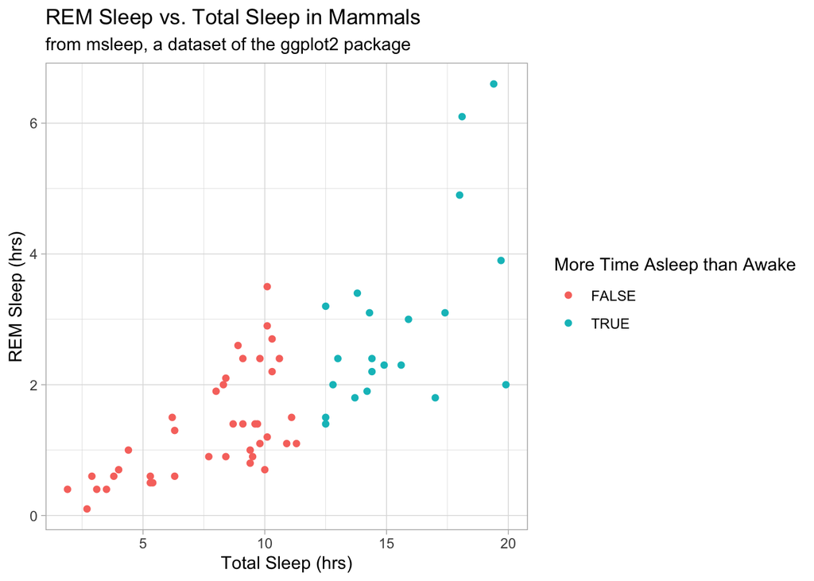

```r
ggplot(data = mammal, mapping = aes(x = sleep_total, y = sleep_rem, color = sleepy)) +
  geom_point() +
  theme_light() +
  labs(title = "REM Sleep vs. Total Sleep in Mammals",
       subtitle = "from msleep, a dataset of the ggplot2 package",
       x = "Total Sleep (hrs)",
       y = "REM Sleep (hrs)",
       color = "More Time Asleep than Awake")
```

You may need to filter out NAs before plotting – R does it automatically here.

- data is always the first argument (can go over piping operator exception)
- within `aes()` (short for aesthetics), assign variables to the x/y axes and other elements of the plot
- use another layer to specify the kind of plot – `geom_point()`, `geom_histogram()`, and `geom_boxplot()` are a few common examples
- add a theme to manipulate the appearance of your plot – `theme_light()` and `theme_classic()` are two of many options
- use `labs()` to add labels
- tip: use `alpha()` for transparency on crowded scatterplots

Notes on `theme()`: You can build highly cutomized plots by formatting the non-data elements with arguments within `theme()`. See [this link](https://ggplot2.tidyverse.org/reference/theme.html) for a list of optional arguments. This is great for adding horizontal/vertical lines and other annotations to tell the story of your data.

Now let’s create a boxplot – these are helpful for visualizing categorical variables.

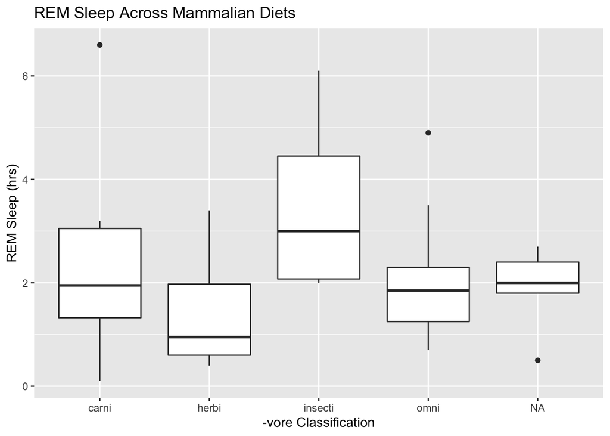

```r
ggplot(data = mammal, aes(x = vore, y = sleep_rem)) +
  geom_boxplot() +
  labs(title = "REM Sleep Across Mammalian Diets",
       y = "REM Sleep (hrs)",
       x = "-vore Classification")
```

Note that we didn’t add a theme here – this is the default appearance for plots using ggplot2.

**Now play with ggplot2 and the other skills you’ve learned to create a plot that interests you.**